# Risk Factor Analysis

## Outcome Variable

**Outcome Variable:** y_rate_haz

## Predictor Variables

**Intervention Variable:** cleanck

**Adjustment Set:**

unadjusted

## Stratifying Variables

The analysis was stratified on these variable(s):

- agecat
- studyid
- country

## Data Summary

| agecat | studyid | country | cleanck | n_cell | n |
| --- | --- | --- | --- | --- | --- |
| 0-3 months | ki0047075b-MAL-ED | PERU | 1 | 1 | 1 |
| 0-3 months | ki0047075b-MAL-ED | PERU | 0 | 0 | 1 |
| 0-3 months | ki0047075b-MAL-ED | SOUTH AFRICA | 1 | 1 | 2 |
| 0-3 months | ki0047075b-MAL-ED | SOUTH AFRICA | 0 | 1 | 2 |
| 0-3 months | ki1000108-CMC-V-BCS-2002 | INDIA | 1 | 40 | 88 |
| 0-3 months | ki1000108-CMC-V-BCS-2002 | INDIA | 0 | 48 | 88 |
| 0-3 months | ki1000108-IRC | INDIA | 1 | 212 | 369 |
| 0-3 months | ki1000108-IRC | INDIA | 0 | 157 | 369 |
| 0-3 months | ki1017093b-PROVIDE | BANGLADESH | 1 | 529 | 640 |
| 0-3 months | ki1017093b-PROVIDE | BANGLADESH | 0 | 111 | 640 |
| 0-3 months | ki1017093c-NIH-Crypto | BANGLADESH | 1 | 334 | 547 |
| 0-3 months | ki1017093c-NIH-Crypto | BANGLADESH | 0 | 213 | 547 |
| 0-3 months | ki1113344-GMS-Nepal | NEPAL | 1 | 6 | 460 |
| 0-3 months | ki1113344-GMS-Nepal | NEPAL | 0 | 454 | 460 |
| 3-6 months | ki0047075b-MAL-ED | SOUTH AFRICA | 1 | 1 | 1 |
| 3-6 months | ki0047075b-MAL-ED | SOUTH AFRICA | 0 | 0 | 1 |
| 3-6 months | ki1000108-CMC-V-BCS-2002 | INDIA | 1 | 133 | 307 |
| 3-6 months | ki1000108-CMC-V-BCS-2002 | INDIA | 0 | 174 | 307 |
| 3-6 months | ki1000108-IRC | INDIA | 1 | 224 | 390 |
| 3-6 months | ki1000108-IRC | INDIA | 0 | 166 | 390 |
| 3-6 months | ki1017093b-PROVIDE | BANGLADESH | 1 | 492 | 598 |
| 3-6 months | ki1017093b-PROVIDE | BANGLADESH | 0 | 106 | 598 |
| 3-6 months | ki1017093c-NIH-Crypto | BANGLADESH | 1 | 315 | 527 |
| 3-6 months | ki1017093c-NIH-Crypto | BANGLADESH | 0 | 212 | 527 |
| 3-6 months | ki1113344-GMS-Nepal | NEPAL | 1 | 6 | 424 |
| 3-6 months | ki1113344-GMS-Nepal | NEPAL | 0 | 418 | 424 |
| 6-9 months | ki0047075b-MAL-ED | SOUTH AFRICA | 1 | 1 | 1 |
| 6-9 months | ki0047075b-MAL-ED | SOUTH AFRICA | 0 | 0 | 1 |
| 6-9 months | ki1000108-CMC-V-BCS-2002 | INDIA | 1 | 136 | 313 |
| 6-9 months | ki1000108-CMC-V-BCS-2002 | INDIA | 0 | 177 | 313 |

[output cut: 68 more lines]

The following strata were considered:

- agecat: 0-3 months, studyid: ki0047075b-MAL-ED, country: PERU
- agecat: 0-3 months, studyid: ki0047075b-MAL-ED, country: SOUTH AFRICA
- agecat: 0-3 months, studyid: ki1000108-CMC-V-BCS-2002, country: INDIA
- agecat: 0-3 months, studyid: ki1000108-IRC, country: INDIA
- agecat: 0-3 months, studyid: ki1017093b-PROVIDE, country: BANGLADESH
- agecat: 0-3 months, studyid: ki1017093c-NIH-Crypto, country: BANGLADESH
- agecat: 0-3 months, studyid: ki1113344-GMS-Nepal, country: NEPAL
- agecat: 12-15 months, studyid: ki0047075b-MAL-ED, country: SOUTH AFRICA
- agecat: 12-15 months, studyid: ki1000108-CMC-V-BCS-2002, country: INDIA
- agecat: 12-15 months, studyid: ki1000108-IRC, country: INDIA
- agecat: 12-15 months, studyid: ki1017093b-PROVIDE, country: BANGLADESH
- agecat: 12-15 months, studyid: ki1017093c-NIH-Crypto, country: BANGLADESH
- agecat: 12-15 months, studyid: ki1113344-GMS-Nepal, country: NEPAL
- agecat: 15-18 months, studyid: ki0047075b-MAL-ED, country: SOUTH AFRICA
- agecat: 15-18 months, studyid: ki1000108-CMC-V-BCS-2002, country: INDIA
- agecat: 15-18 months, studyid: ki1000108-IRC, country: INDIA
- agecat: 15-18 months, studyid: ki1017093b-PROVIDE, country: BANGLADESH
- agecat: 15-18 months, studyid: ki1017093c-NIH-Crypto, country: BANGLADESH
- agecat: 15-18 months, studyid: ki1113344-GMS-Nepal, country: NEPAL
- agecat: 18-21 months, studyid: ki0047075b-MAL-ED, country: SOUTH AFRICA
- agecat: 18-21 months, studyid: ki1000108-CMC-V-BCS-2002, country: INDIA
- agecat: 18-21 months, studyid: ki1000108-IRC, country: INDIA
- agecat: 18-21 months, studyid: ki1017093b-PROVIDE, country: BANGLADESH
- agecat: 18-21 months, studyid: ki1017093c-NIH-Crypto, country: BANGLADESH
- agecat: 18-21 months, studyid: ki1113344-GMS-Nepal, country: NEPAL
- agecat: 21-24 months, studyid: ki0047075b-MAL-ED, country: SOUTH AFRICA
- agecat: 21-24 months, studyid: ki1000108-CMC-V-BCS-2002, country: INDIA
- agecat: 21-24 months, studyid: ki1000108-IRC, country: INDIA
- agecat: 21-24 months, studyid: ki1017093b-PROVIDE, country: BANGLADESH
- agecat: 21-24 months, studyid: ki1017093c-NIH-Crypto, country: BANGLADESH
- agecat: 21-24 months, studyid: ki1113344-GMS-Nepal, country: NEPAL
- agecat: 3-6 months, studyid: ki0047075b-MAL-ED, country: SOUTH AFRICA
- agecat: 3-6 months, studyid: ki1000108-CMC-V-BCS-2002, country: INDIA
- agecat: 3-6 months, studyid: ki1000108-IRC, country: INDIA
- agecat: 3-6 months, studyid: ki1017093b-PROVIDE, country: BANGLADESH
- agecat: 3-6 months, studyid: ki1017093c-NIH-Crypto, country: BANGLADESH
- agecat: 3-6 months, studyid: ki1113344-GMS-Nepal, country: NEPAL
- agecat: 6-9 months, studyid: ki0047075b-MAL-ED, country: SOUTH AFRICA
- agecat: 6-9 months, studyid: ki1000108-CMC-V-BCS-2002, country: INDIA
- agecat: 6-9 months, studyid: ki1000108-IRC, country: INDIA
- agecat: 6-9 months, studyid: ki1017093b-PROVIDE, country: BANGLADESH
- agecat: 6-9 months, studyid: ki1017093c-NIH-Crypto, country: BANGLADESH
- agecat: 6-9 months, studyid: ki1113344-GMS-Nepal, country: NEPAL
- agecat: 9-12 months, studyid: ki0047075b-MAL-ED, country: SOUTH AFRICA
- agecat: 9-12 months, studyid: ki1000108-CMC-V-BCS-2002, country: INDIA
- agecat: 9-12 months, studyid: ki1000108-IRC, country: INDIA
- agecat: 9-12 months, studyid: ki1017093b-PROVIDE, country: BANGLADESH
- agecat: 9-12 months, studyid: ki1017093c-NIH-Crypto, country: BANGLADESH
- agecat: 9-12 months, studyid: ki1113344-GMS-Nepal, country: NEPAL

### Dropped Strata

Some strata were dropped due to rare outcomes:

- agecat: 0-3 months, studyid: ki0047075b-MAL-ED, country: PERU
- agecat: 0-3 months, studyid: ki0047075b-MAL-ED, country: SOUTH AFRICA
- agecat: 3-6 months, studyid: ki0047075b-MAL-ED, country: SOUTH AFRICA
- agecat: 6-9 months, studyid: ki0047075b-MAL-ED, country: SOUTH AFRICA
- agecat: 9-12 months, studyid: ki0047075b-MAL-ED, country: SOUTH AFRICA
- agecat: 12-15 months, studyid: ki0047075b-MAL-ED, country: SOUTH AFRICA
- agecat: 15-18 months, studyid: ki0047075b-MAL-ED, country: SOUTH AFRICA
- agecat: 18-21 months, studyid: ki0047075b-MAL-ED, country: SOUTH AFRICA
- agecat: 21-24 months, studyid: ki0047075b-MAL-ED, country: SOUTH AFRICA
- agecat: 21-24 months, studyid: ki1113344-GMS-Nepal, country: NEPAL

## Methods Detail

We’re interested in the causal parameters $E[Y_a]$ for all values of $a \in \mathcal{A}$. These parameters represent the mean outcome if, possibly contrary to fact, we intervened to set all units to have $A=a$. Under the randomization and positivity assumptions, these are identified by the statistical parameters $\psi_a=E_W[E_{Y|A,W}(Y|A=a,W)]$. In addition, we’re interested in the mean of $Y$, $E[Y]$ under no intervention (the observed mean). We will estimate these parameters by using SuperLearner to fit the relevant likelihood factors – $E_{Y|A,W}(Y|A=a,W)$ and $p(A=a|W)$, and then updating our likelihood fit using a joint TMLE.

For unadjusted analyses ($W=\{\}$), initial likelihoods were estimated using Lrnr_glm to estimate the simple $E(Y|A)$ and Lrnr_mean to estimate $p(A)$. For adjusted analyses, a small library containing Lrnr_glmnet, Lrnr_xgboost, and Lrnr_mean was used.

Having estimated these parameters, we will then use the delta method to estimate relative risks and attributable risks relative to a prespecified baseline level of $A$.

# Results Detail

## Results Plots

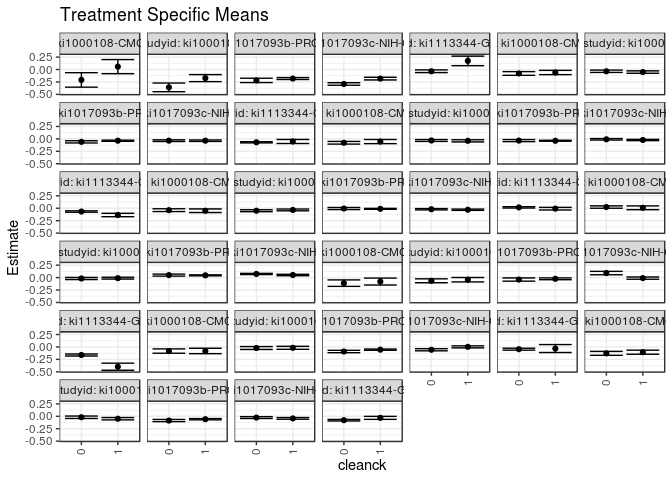

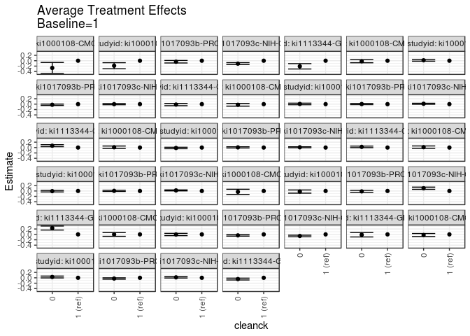

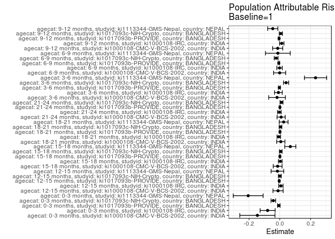

## Results Table

### Parameter: TSM

| agecat | studyid | country | intervention_level | baseline_level | estimate | ci_lower | ci_upper |
| --- | --- | --- | --- | --- | --- | --- | --- |
| 0-3 months | ki1000108-CMC-V-BCS-2002 | INDIA | 1 | NA | 0.0579061 | -0.0837153 | 0.1995275 |
| 0-3 months | ki1000108-CMC-V-BCS-2002 | INDIA | 0 | NA | -0.2092925 | -0.3548044 | -0.0637805 |
| 0-3 months | ki1000108-IRC | INDIA | 1 | NA | -0.1728369 | -0.2436314 | -0.1020424 |
| 0-3 months | ki1000108-IRC | INDIA | 0 | NA | -0.3589492 | -0.4460276 | -0.2718709 |
| 0-3 months | ki1017093b-PROVIDE | BANGLADESH | 1 | NA | -0.1815644 | -0.2004830 | -0.1626458 |
| 0-3 months | ki1017093b-PROVIDE | BANGLADESH | 0 | NA | -0.2189023 | -0.2620618 | -0.1757427 |
| 0-3 months | ki1017093c-NIH-Crypto | BANGLADESH | 1 | NA | -0.1826945 | -0.2093853 | -0.1560037 |
| 0-3 months | ki1017093c-NIH-Crypto | BANGLADESH | 0 | NA | -0.2909872 | -0.3162143 | -0.2657601 |
| 0-3 months | ki1113344-GMS-Nepal | NEPAL | 1 | NA | 0.1731986 | 0.0774761 | 0.2689210 |
| 0-3 months | ki1113344-GMS-Nepal | NEPAL | 0 | NA | -0.0350183 | -0.0621623 | -0.0078743 |
| 3-6 months | ki1000108-CMC-V-BCS-2002 | INDIA | 1 | NA | -0.0800404 | -0.1498831 | -0.0101977 |
| 3-6 months | ki1000108-CMC-V-BCS-2002 | INDIA | 0 | NA | -0.1116598 | -0.1764945 | -0.0468252 |
| 3-6 months | ki1000108-IRC | INDIA | 1 | NA | -0.0425010 | -0.0870207 | 0.0020187 |
| 3-6 months | ki1000108-IRC | INDIA | 0 | NA | -0.0642886 | -0.1031990 | -0.0253782 |
| 3-6 months | ki1017093b-PROVIDE | BANGLADESH | 1 | NA | -0.0242945 | -0.0422999 | -0.0062891 |
| 3-6 months | ki1017093b-PROVIDE | BANGLADESH | 0 | NA | -0.0393461 | -0.0718318 | -0.0068603 |
| 3-6 months | ki1017093c-NIH-Crypto | BANGLADESH | 1 | NA | -0.0104667 | -0.0328936 | 0.0119601 |
| 3-6 months | ki1017093c-NIH-Crypto | BANGLADESH | 0 | NA | 0.0907843 | 0.0564599 | 0.1251088 |
| 3-6 months | ki1113344-GMS-Nepal | NEPAL | 1 | NA | -0.3974205 | -0.4687983 | -0.3260427 |
| 3-6 months | ki1113344-GMS-Nepal | NEPAL | 0 | NA | -0.1617840 | -0.1819009 | -0.1416670 |
| 6-9 months | ki1000108-CMC-V-BCS-2002 | INDIA | 1 | NA | -0.0809157 | -0.1351818 | -0.0266495 |
| 6-9 months | ki1000108-CMC-V-BCS-2002 | INDIA | 0 | NA | -0.0827724 | -0.1265838 | -0.0389609 |
| 6-9 months | ki1000108-IRC | INDIA | 1 | NA | -0.0174993 | -0.0472837 | 0.0122851 |
| 6-9 months | ki1000108-IRC | INDIA | 0 | NA | -0.0213987 | -0.0506521 | 0.0078547 |
| 6-9 months | ki1017093b-PROVIDE | BANGLADESH | 1 | NA | -0.0547504 | -0.0668063 | -0.0426946 |
| 6-9 months | ki1017093b-PROVIDE | BANGLADESH | 0 | NA | -0.0913709 | -0.1152927 | -0.0674491 |
| 6-9 months | ki1017093c-NIH-Crypto | BANGLADESH | 1 | NA | 0.0019721 | -0.0182329 | 0.0221770 |
| 6-9 months | ki1017093c-NIH-Crypto | BANGLADESH | 0 | NA | -0.0566343 | -0.0780579 | -0.0352107 |
| 6-9 months | ki1113344-GMS-Nepal | NEPAL | 1 | NA | -0.0321023 | -0.1124147 | 0.0482102 |
| 6-9 months | ki1113344-GMS-Nepal | NEPAL | 0 | NA | -0.0450512 | -0.0643517 | -0.0257508 |
| 9-12 months | ki1000108-CMC-V-BCS-2002 | INDIA | 1 | NA | -0.1049542 | -0.1455974 | -0.0643111 |
| 9-12 months | ki1000108-CMC-V-BCS-2002 | INDIA | 0 | NA | -0.1287059 | -0.1679779 | -0.0894340 |
| 9-12 months | ki1000108-IRC | INDIA | 1 | NA | -0.0487200 | -0.0722130 | -0.0252271 |
| 9-12 months | ki1000108-IRC | INDIA | 0 | NA | -0.0186757 | -0.0432174 | 0.0058660 |
| 9-12 months | ki1017093b-PROVIDE | BANGLADESH | 1 | NA | -0.0581867 | -0.0706112 | -0.0457623 |
| 9-12 months | ki1017093b-PROVIDE | BANGLADESH | 0 | NA | -0.0851565 | -0.1072804 | -0.0630325 |
| 9-12 months | ki1017093c-NIH-Crypto | BANGLADESH | 1 | NA | -0.0420476 | -0.0588406 | -0.0252545 |
| 9-12 months | ki1017093c-NIH-Crypto | BANGLADESH | 0 | NA | -0.0255252 | -0.0439986 | -0.0070518 |
| 9-12 months | ki1113344-GMS-Nepal | NEPAL | 1 | NA | -0.0314007 | -0.0618148 | -0.0009866 |
| 9-12 months | ki1113344-GMS-Nepal | NEPAL | 0 | NA | -0.0780277 | -0.0930251 | -0.0630303 |
| 12-15 months | ki1000108-CMC-V-BCS-2002 | INDIA | 1 | NA | -0.0598186 | -0.1026936 | -0.0169437 |
| 12-15 months | ki1000108-CMC-V-BCS-2002 | INDIA | 0 | NA | -0.0792773 | -0.1160607 | -0.0424940 |
| 12-15 months | ki1000108-IRC | INDIA | 1 | NA | -0.0514631 | -0.0756113 | -0.0273148 |
| 12-15 months | ki1000108-IRC | INDIA | 0 | NA | -0.0351970 | -0.0583302 | -0.0120638 |
| 12-15 months | ki1017093b-PROVIDE | BANGLADESH | 1 | NA | -0.0370429 | -0.0482785 | -0.0258074 |
| 12-15 months | ki1017093b-PROVIDE | BANGLADESH | 0 | NA | -0.0596546 | -0.0820172 | -0.0372919 |
| 12-15 months | ki1017093c-NIH-Crypto | BANGLADESH | 1 | NA | -0.0367068 | -0.0515327 | -0.0218808 |
| 12-15 months | ki1017093c-NIH-Crypto | BANGLADESH | 0 | NA | -0.0362671 | -0.0527184 | -0.0198158 |
| 12-15 months | ki1113344-GMS-Nepal | NEPAL | 1 | NA | -0.0525575 | -0.0932027 | -0.0119122 |
| 12-15 months | ki1113344-GMS-Nepal | NEPAL | 0 | NA | -0.0684343 | -0.0802563 | -0.0566123 |
| 15-18 months | ki1000108-CMC-V-BCS-2002 | INDIA | 1 | NA | -0.0540725 | -0.0954041 | -0.0127409 |
| 15-18 months | ki1000108-CMC-V-BCS-2002 | INDIA | 0 | NA | -0.0782589 | -0.1052480 | -0.0512699 |
| 15-18 months | ki1000108-IRC | INDIA | 1 | NA | -0.0397542 | -0.0616089 | -0.0178996 |
| 15-18 months | ki1000108-IRC | INDIA | 0 | NA | -0.0326545 | -0.0513423 | -0.0139668 |
| 15-18 months | ki1017093b-PROVIDE | BANGLADESH | 1 | NA | -0.0382304 | -0.0478959 | -0.0285650 |
| 15-18 months | ki1017093b-PROVIDE | BANGLADESH | 0 | NA | -0.0347883 | -0.0552518 | -0.0143249 |
| 15-18 months | ki1017093c-NIH-Crypto | BANGLADESH | 1 | NA | -0.0224434 | -0.0351600 | -0.0097269 |
| 15-18 months | ki1017093c-NIH-Crypto | BANGLADESH | 0 | NA | -0.0087895 | -0.0233201 | 0.0057410 |
| 15-18 months | ki1113344-GMS-Nepal | NEPAL | 1 | NA | -0.1358700 | -0.1700189 | -0.1017211 |
| 15-18 months | ki1113344-GMS-Nepal | NEPAL | 0 | NA | -0.0662360 | -0.0800615 | -0.0524104 |
| 18-21 months | ki1000108-CMC-V-BCS-2002 | INDIA | 1 | NA | -0.0503369 | -0.0864009 | -0.0142729 |
| 18-21 months | ki1000108-CMC-V-BCS-2002 | INDIA | 0 | NA | -0.0390774 | -0.0674042 | -0.0107506 |
| 18-21 months | ki1000108-IRC | INDIA | 1 | NA | -0.0342084 | -0.0526854 | -0.0157314 |
| 18-21 months | ki1000108-IRC | INDIA | 0 | NA | -0.0500582 | -0.0692541 | -0.0308623 |
| 18-21 months | ki1017093b-PROVIDE | BANGLADESH | 1 | NA | -0.0120383 | -0.0208918 | -0.0031848 |
| 18-21 months | ki1017093b-PROVIDE | BANGLADESH | 0 | NA | -0.0060961 | -0.0266528 | 0.0144606 |
| 18-21 months | ki1017093c-NIH-Crypto | BANGLADESH | 1 | NA | -0.0300446 | -0.0426852 | -0.0174039 |
| 18-21 months | ki1017093c-NIH-Crypto | BANGLADESH | 0 | NA | -0.0204590 | -0.0333131 | -0.0076050 |
| 18-21 months | ki1113344-GMS-Nepal | NEPAL | 1 | NA | -0.0084094 | -0.0345648 | 0.0177460 |
| 18-21 months | ki1113344-GMS-Nepal | NEPAL | 0 | NA | 0.0169791 | 0.0040007 | 0.0299576 |
| 21-24 months | ki1000108-CMC-V-BCS-2002 | INDIA | 1 | NA | 0.0091230 | -0.0287319 | 0.0469779 |
| 21-24 months | ki1000108-CMC-V-BCS-2002 | INDIA | 0 | NA | 0.0235604 | -0.0004636 | 0.0475845 |
| 21-24 months | ki1000108-IRC | INDIA | 1 | NA | -0.0112086 | -0.0298099 | 0.0073928 |
| 21-24 months | ki1000108-IRC | INDIA | 0 | NA | -0.0180978 | -0.0388190 | 0.0026234 |
| 21-24 months | ki1017093b-PROVIDE | BANGLADESH | 1 | NA | 0.0454126 | 0.0358573 | 0.0549678 |
| 21-24 months | ki1017093b-PROVIDE | BANGLADESH | 0 | NA | 0.0500198 | 0.0297217 | 0.0703179 |
| 21-24 months | ki1017093c-NIH-Crypto | BANGLADESH | 1 | NA | 0.0523623 | 0.0387294 | 0.0659953 |
| 21-24 months | ki1017093c-NIH-Crypto | BANGLADESH | 0 | NA | 0.0731405 | 0.0614262 | 0.0848548 |

### Parameter: E(Y)

| agecat | studyid | country | intervention_level | baseline_level | estimate | ci_lower | ci_upper |
| --- | --- | --- | --- | --- | --- | --- | --- |
| 0-3 months | ki1000108-CMC-V-BCS-2002 | INDIA | NA | NA | -0.0878386 | -0.1937874 | 0.0181102 |
| 0-3 months | ki1000108-IRC | INDIA | NA | NA | -0.2520229 | -0.3078384 | -0.1962074 |
| 0-3 months | ki1017093b-PROVIDE | BANGLADESH | NA | NA | -0.1880402 | -0.2054115 | -0.1706689 |
| 0-3 months | ki1017093c-NIH-Crypto | BANGLADESH | NA | NA | -0.2248633 | -0.2444011 | -0.2053256 |
| 0-3 months | ki1113344-GMS-Nepal | NEPAL | NA | NA | -0.0323024 | -0.0589635 | -0.0056413 |
| 3-6 months | ki1000108-CMC-V-BCS-2002 | INDIA | NA | NA | -0.0979615 | -0.1455947 | -0.0503283 |
| 3-6 months | ki1000108-IRC | INDIA | NA | NA | -0.0517747 | -0.0822588 | -0.0212906 |
| 3-6 months | ki1017093b-PROVIDE | BANGLADESH | NA | NA | -0.0269625 | -0.0428628 | -0.0110622 |
| 3-6 months | ki1017093c-NIH-Crypto | BANGLADESH | NA | NA | 0.0302642 | 0.0105575 | 0.0499710 |
| 3-6 months | ki1113344-GMS-Nepal | NEPAL | NA | NA | -0.1651184 | -0.1849912 | -0.1452456 |
| 6-9 months | ki1000108-CMC-V-BCS-2002 | INDIA | NA | NA | -0.0819656 | -0.1161677 | -0.0477635 |
| 6-9 months | ki1000108-IRC | INDIA | NA | NA | -0.0191453 | -0.0403295 | 0.0020389 |
| 6-9 months | ki1017093b-PROVIDE | BANGLADESH | NA | NA | -0.0614264 | -0.0722690 | -0.0505838 |
| 6-9 months | ki1017093c-NIH-Crypto | BANGLADESH | NA | NA | -0.0219170 | -0.0369369 | -0.0068971 |
| 6-9 months | ki1113344-GMS-Nepal | NEPAL | NA | NA | -0.0448120 | -0.0637374 | -0.0258865 |
| 9-12 months | ki1000108-CMC-V-BCS-2002 | INDIA | NA | NA | -0.1188156 | -0.1473352 | -0.0902961 |
| 9-12 months | ki1000108-IRC | INDIA | NA | NA | -0.0361183 | -0.0532692 | -0.0189675 |
| 9-12 months | ki1017093b-PROVIDE | BANGLADESH | NA | NA | -0.0630470 | -0.0740183 | -0.0520757 |
| 9-12 months | ki1017093c-NIH-Crypto | BANGLADESH | NA | NA | -0.0352217 | -0.0477064 | -0.0227371 |
| 9-12 months | ki1113344-GMS-Nepal | NEPAL | NA | NA | -0.0771479 | -0.0918027 | -0.0624932 |
| 12-15 months | ki1000108-CMC-V-BCS-2002 | INDIA | NA | NA | -0.0712336 | -0.0991765 | -0.0432907 |
| 12-15 months | ki1000108-IRC | INDIA | NA | NA | -0.0446142 | -0.0616724 | -0.0275560 |
| 12-15 months | ki1017093b-PROVIDE | BANGLADESH | NA | NA | -0.0409107 | -0.0510053 | -0.0308161 |
| 12-15 months | ki1017093c-NIH-Crypto | BANGLADESH | NA | NA | -0.0365229 | -0.0475564 | -0.0254894 |
| 12-15 months | ki1113344-GMS-Nepal | NEPAL | NA | NA | -0.0681340 | -0.0797070 | -0.0565610 |
| 15-18 months | ki1000108-CMC-V-BCS-2002 | INDIA | NA | NA | -0.0680871 | -0.0915055 | -0.0446686 |
| 15-18 months | ki1000108-IRC | INDIA | NA | NA | -0.0367739 | -0.0516890 | -0.0218588 |
| 15-18 months | ki1017093b-PROVIDE | BANGLADESH | NA | NA | -0.0376437 | -0.0463882 | -0.0288992 |
| 15-18 months | ki1017093c-NIH-Crypto | BANGLADESH | NA | NA | -0.0162904 | -0.0258853 | -0.0066955 |
| 15-18 months | ki1113344-GMS-Nepal | NEPAL | NA | NA | -0.0675196 | -0.0810553 | -0.0539839 |
| 18-21 months | ki1000108-CMC-V-BCS-2002 | INDIA | NA | NA | -0.0437658 | -0.0661084 | -0.0214232 |
| 18-21 months | ki1000108-IRC | INDIA | NA | NA | -0.0410011 | -0.0544100 | -0.0275923 |
| 18-21 months | ki1017093b-PROVIDE | BANGLADESH | NA | NA | -0.0109399 | -0.0190984 | -0.0027814 |
| 18-21 months | ki1017093c-NIH-Crypto | BANGLADESH | NA | NA | -0.0253964 | -0.0344213 | -0.0163714 |
| 18-21 months | ki1113344-GMS-Nepal | NEPAL | NA | NA | 0.0165414 | 0.0038665 | 0.0292163 |
| 21-24 months | ki1000108-CMC-V-BCS-2002 | INDIA | NA | NA | 0.0177011 | -0.0032847 | 0.0386869 |
| 21-24 months | ki1000108-IRC | INDIA | NA | NA | -0.0141818 | -0.0280342 | -0.0003294 |
| 21-24 months | ki1017093b-PROVIDE | BANGLADESH | NA | NA | 0.0462342 | 0.0375872 | 0.0548812 |
| 21-24 months | ki1017093c-NIH-Crypto | BANGLADESH | NA | NA | 0.0634123 | 0.0544343 | 0.0723903 |

### Parameter: ATE

| agecat | studyid | country | intervention_level | baseline_level | estimate | ci_lower | ci_upper |
| --- | --- | --- | --- | --- | --- | --- | --- |
| 0-3 months | ki1000108-CMC-V-BCS-2002 | INDIA | 1 | 1 | 0.0000000 | 0.0000000 | 0.0000000 |
| 0-3 months | ki1000108-CMC-V-BCS-2002 | INDIA | 0 | 1 | -0.2671985 | -0.4702512 | -0.0641459 |
| 0-3 months | ki1000108-IRC | INDIA | 1 | 1 | 0.0000000 | 0.0000000 | 0.0000000 |
| 0-3 months | ki1000108-IRC | INDIA | 0 | 1 | -0.1861123 | -0.2983375 | -0.0738871 |
| 0-3 months | ki1017093b-PROVIDE | BANGLADESH | 1 | 1 | 0.0000000 | 0.0000000 | 0.0000000 |
| 0-3 months | ki1017093b-PROVIDE | BANGLADESH | 0 | 1 | -0.0373379 | -0.0844617 | 0.0097860 |
| 0-3 months | ki1017093c-NIH-Crypto | BANGLADESH | 1 | 1 | 0.0000000 | 0.0000000 | 0.0000000 |
| 0-3 months | ki1017093c-NIH-Crypto | BANGLADESH | 0 | 1 | -0.1082927 | -0.1450187 | -0.0715667 |
| 0-3 months | ki1113344-GMS-Nepal | NEPAL | 1 | 1 | 0.0000000 | 0.0000000 | 0.0000000 |
| 0-3 months | ki1113344-GMS-Nepal | NEPAL | 0 | 1 | -0.2082168 | -0.3077134 | -0.1087202 |
| 3-6 months | ki1000108-CMC-V-BCS-2002 | INDIA | 1 | 1 | 0.0000000 | 0.0000000 | 0.0000000 |
| 3-6 months | ki1000108-CMC-V-BCS-2002 | INDIA | 0 | 1 | -0.0316194 | -0.1269165 | 0.0636776 |
| 3-6 months | ki1000108-IRC | INDIA | 1 | 1 | 0.0000000 | 0.0000000 | 0.0000000 |
| 3-6 months | ki1000108-IRC | INDIA | 0 | 1 | -0.0217876 | -0.0809148 | 0.0373396 |
| 3-6 months | ki1017093b-PROVIDE | BANGLADESH | 1 | 1 | 0.0000000 | 0.0000000 | 0.0000000 |
| 3-6 months | ki1017093b-PROVIDE | BANGLADESH | 0 | 1 | -0.0150516 | -0.0521935 | 0.0220903 |
| 3-6 months | ki1017093c-NIH-Crypto | BANGLADESH | 1 | 1 | 0.0000000 | 0.0000000 | 0.0000000 |
| 3-6 months | ki1017093c-NIH-Crypto | BANGLADESH | 0 | 1 | 0.1012511 | 0.0602495 | 0.1422527 |
| 3-6 months | ki1113344-GMS-Nepal | NEPAL | 1 | 1 | 0.0000000 | 0.0000000 | 0.0000000 |
| 3-6 months | ki1113344-GMS-Nepal | NEPAL | 0 | 1 | 0.2356365 | 0.1614780 | 0.3097950 |
| 6-9 months | ki1000108-CMC-V-BCS-2002 | INDIA | 1 | 1 | 0.0000000 | 0.0000000 | 0.0000000 |
| 6-9 months | ki1000108-CMC-V-BCS-2002 | INDIA | 0 | 1 | -0.0018567 | -0.0716009 | 0.0678875 |
| 6-9 months | ki1000108-IRC | INDIA | 1 | 1 | 0.0000000 | 0.0000000 | 0.0000000 |
| 6-9 months | ki1000108-IRC | INDIA | 0 | 1 | -0.0038994 | -0.0456471 | 0.0378484 |
| 6-9 months | ki1017093b-PROVIDE | BANGLADESH | 1 | 1 | 0.0000000 | 0.0000000 | 0.0000000 |
| 6-9 months | ki1017093b-PROVIDE | BANGLADESH | 0 | 1 | -0.0366205 | -0.0634085 | -0.0098325 |
| 6-9 months | ki1017093c-NIH-Crypto | BANGLADESH | 1 | 1 | 0.0000000 | 0.0000000 | 0.0000000 |
| 6-9 months | ki1017093c-NIH-Crypto | BANGLADESH | 0 | 1 | -0.0586063 | -0.0880547 | -0.0291579 |
| 6-9 months | ki1113344-GMS-Nepal | NEPAL | 1 | 1 | 0.0000000 | 0.0000000 | 0.0000000 |
| 6-9 months | ki1113344-GMS-Nepal | NEPAL | 0 | 1 | -0.0129489 | -0.0955480 | 0.0696501 |
| 9-12 months | ki1000108-CMC-V-BCS-2002 | INDIA | 1 | 1 | 0.0000000 | 0.0000000 | 0.0000000 |
| 9-12 months | ki1000108-CMC-V-BCS-2002 | INDIA | 0 | 1 | -0.0237517 | -0.0802685 | 0.0327651 |
| 9-12 months | ki1000108-IRC | INDIA | 1 | 1 | 0.0000000 | 0.0000000 | 0.0000000 |
| 9-12 months | ki1000108-IRC | INDIA | 0 | 1 | 0.0300443 | -0.0039294 | 0.0640180 |
| 9-12 months | ki1017093b-PROVIDE | BANGLADESH | 1 | 1 | 0.0000000 | 0.0000000 | 0.0000000 |
| 9-12 months | ki1017093b-PROVIDE | BANGLADESH | 0 | 1 | -0.0269697 | -0.0523437 | -0.0015958 |
| 9-12 months | ki1017093c-NIH-Crypto | BANGLADESH | 1 | 1 | 0.0000000 | 0.0000000 | 0.0000000 |
| 9-12 months | ki1017093c-NIH-Crypto | BANGLADESH | 0 | 1 | 0.0165224 | -0.0084431 | 0.0414878 |
| 9-12 months | ki1113344-GMS-Nepal | NEPAL | 1 | 1 | 0.0000000 | 0.0000000 | 0.0000000 |
| 9-12 months | ki1113344-GMS-Nepal | NEPAL | 0 | 1 | -0.0466270 | -0.0805378 | -0.0127163 |
| 12-15 months | ki1000108-CMC-V-BCS-2002 | INDIA | 1 | 1 | 0.0000000 | 0.0000000 | 0.0000000 |
| 12-15 months | ki1000108-CMC-V-BCS-2002 | INDIA | 0 | 1 | -0.0194587 | -0.0759501 | 0.0370327 |
| 12-15 months | ki1000108-IRC | INDIA | 1 | 1 | 0.0000000 | 0.0000000 | 0.0000000 |
| 12-15 months | ki1000108-IRC | INDIA | 0 | 1 | 0.0162661 | -0.0171747 | 0.0497068 |
| 12-15 months | ki1017093b-PROVIDE | BANGLADESH | 1 | 1 | 0.0000000 | 0.0000000 | 0.0000000 |
| 12-15 months | ki1017093b-PROVIDE | BANGLADESH | 0 | 1 | -0.0226116 | -0.0476381 | 0.0024148 |
| 12-15 months | ki1017093c-NIH-Crypto | BANGLADESH | 1 | 1 | 0.0000000 | 0.0000000 | 0.0000000 |
| 12-15 months | ki1017093c-NIH-Crypto | BANGLADESH | 0 | 1 | 0.0004396 | -0.0217065 | 0.0225858 |
| 12-15 months | ki1113344-GMS-Nepal | NEPAL | 1 | 1 | 0.0000000 | 0.0000000 | 0.0000000 |
| 12-15 months | ki1113344-GMS-Nepal | NEPAL | 0 | 1 | -0.0158768 | -0.0582064 | 0.0264528 |
| 15-18 months | ki1000108-CMC-V-BCS-2002 | INDIA | 1 | 1 | 0.0000000 | 0.0000000 | 0.0000000 |
| 15-18 months | ki1000108-CMC-V-BCS-2002 | INDIA | 0 | 1 | -0.0241864 | -0.0735494 | 0.0251766 |
| 15-18 months | ki1000108-IRC | INDIA | 1 | 1 | 0.0000000 | 0.0000000 | 0.0000000 |
| 15-18 months | ki1000108-IRC | INDIA | 0 | 1 | 0.0070997 | -0.0216554 | 0.0358548 |
| 15-18 months | ki1017093b-PROVIDE | BANGLADESH | 1 | 1 | 0.0000000 | 0.0000000 | 0.0000000 |
| 15-18 months | ki1017093b-PROVIDE | BANGLADESH | 0 | 1 | 0.0034421 | -0.0191892 | 0.0260734 |
| 15-18 months | ki1017093c-NIH-Crypto | BANGLADESH | 1 | 1 | 0.0000000 | 0.0000000 | 0.0000000 |
| 15-18 months | ki1017093c-NIH-Crypto | BANGLADESH | 0 | 1 | 0.0136539 | -0.0056554 | 0.0329632 |
| 15-18 months | ki1113344-GMS-Nepal | NEPAL | 1 | 1 | 0.0000000 | 0.0000000 | 0.0000000 |
| 15-18 months | ki1113344-GMS-Nepal | NEPAL | 0 | 1 | 0.0696340 | 0.0327926 | 0.1064755 |
| 18-21 months | ki1000108-CMC-V-BCS-2002 | INDIA | 1 | 1 | 0.0000000 | 0.0000000 | 0.0000000 |
| 18-21 months | ki1000108-CMC-V-BCS-2002 | INDIA | 0 | 1 | 0.0112594 | -0.0345993 | 0.0571181 |
| 18-21 months | ki1000108-IRC | INDIA | 1 | 1 | 0.0000000 | 0.0000000 | 0.0000000 |
| 18-21 months | ki1000108-IRC | INDIA | 0 | 1 | -0.0158498 | -0.0424934 | 0.0107938 |
| 18-21 months | ki1017093b-PROVIDE | BANGLADESH | 1 | 1 | 0.0000000 | 0.0000000 | 0.0000000 |
| 18-21 months | ki1017093b-PROVIDE | BANGLADESH | 0 | 1 | 0.0059422 | -0.0164400 | 0.0283244 |
| 18-21 months | ki1017093c-NIH-Crypto | BANGLADESH | 1 | 1 | 0.0000000 | 0.0000000 | 0.0000000 |
| 18-21 months | ki1017093c-NIH-Crypto | BANGLADESH | 0 | 1 | 0.0095855 | -0.0084425 | 0.0276136 |
| 18-21 months | ki1113344-GMS-Nepal | NEPAL | 1 | 1 | 0.0000000 | 0.0000000 | 0.0000000 |
| 18-21 months | ki1113344-GMS-Nepal | NEPAL | 0 | 1 | 0.0253885 | -0.0038098 | 0.0545869 |
| 21-24 months | ki1000108-CMC-V-BCS-2002 | INDIA | 1 | 1 | 0.0000000 | 0.0000000 | 0.0000000 |
| 21-24 months | ki1000108-CMC-V-BCS-2002 | INDIA | 0 | 1 | 0.0144374 | -0.0303973 | 0.0592721 |
| 21-24 months | ki1000108-IRC | INDIA | 1 | 1 | 0.0000000 | 0.0000000 | 0.0000000 |
| 21-24 months | ki1000108-IRC | INDIA | 0 | 1 | -0.0068893 | -0.0347348 | 0.0209563 |
| 21-24 months | ki1017093b-PROVIDE | BANGLADESH | 1 | 1 | 0.0000000 | 0.0000000 | 0.0000000 |
| 21-24 months | ki1017093b-PROVIDE | BANGLADESH | 0 | 1 | 0.0046072 | -0.0178275 | 0.0270419 |
| 21-24 months | ki1017093c-NIH-Crypto | BANGLADESH | 1 | 1 | 0.0000000 | 0.0000000 | 0.0000000 |
| 21-24 months | ki1017093c-NIH-Crypto | BANGLADESH | 0 | 1 | 0.0207782 | 0.0028037 | 0.0387527 |

### Parameter: PAR

| agecat | studyid | country | intervention_level | baseline_level | estimate | ci_lower | ci_upper |
| --- | --- | --- | --- | --- | --- | --- | --- |
| 0-3 months | ki1000108-CMC-V-BCS-2002 | INDIA | 1 | NA | -0.1457447 | -0.2599746 | -0.0315147 |
| 0-3 months | ki1000108-IRC | INDIA | 1 | NA | -0.0791860 | -0.1278517 | -0.0305203 |
| 0-3 months | ki1017093b-PROVIDE | BANGLADESH | 1 | NA | -0.0064758 | -0.0147220 | 0.0017704 |
| 0-3 months | ki1017093c-NIH-Crypto | BANGLADESH | 1 | NA | -0.0421688 | -0.0571400 | -0.0271976 |
| 0-3 months | ki1113344-GMS-Nepal | NEPAL | 1 | NA | -0.2055009 | -0.3025342 | -0.1084677 |
| 3-6 months | ki1000108-CMC-V-BCS-2002 | INDIA | 1 | NA | -0.0179211 | -0.0719617 | 0.0361194 |
| 3-6 months | ki1000108-IRC | INDIA | 1 | NA | -0.0092737 | -0.0344634 | 0.0159160 |
| 3-6 months | ki1017093b-PROVIDE | BANGLADESH | 1 | NA | -0.0026680 | -0.0092678 | 0.0039318 |
| 3-6 months | ki1017093c-NIH-Crypto | BANGLADESH | 1 | NA | 0.0407310 | 0.0237000 | 0.0577620 |
| 3-6 months | ki1113344-GMS-Nepal | NEPAL | 1 | NA | 0.2323021 | 0.1599489 | 0.3046552 |
| 6-9 months | ki1000108-CMC-V-BCS-2002 | INDIA | 1 | NA | -0.0010500 | -0.0404901 | 0.0383902 |
| 6-9 months | ki1000108-IRC | INDIA | 1 | NA | -0.0016460 | -0.0192691 | 0.0159772 |
| 6-9 months | ki1017093b-PROVIDE | BANGLADESH | 1 | NA | -0.0066759 | -0.0116969 | -0.0016550 |
| 6-9 months | ki1017093c-NIH-Crypto | BANGLADESH | 1 | NA | -0.0238891 | -0.0361434 | -0.0116347 |
| 6-9 months | ki1113344-GMS-Nepal | NEPAL | 1 | NA | -0.0127097 | -0.0932439 | 0.0678245 |
| 9-12 months | ki1000108-CMC-V-BCS-2002 | INDIA | 1 | NA | -0.0138614 | -0.0468696 | 0.0191469 |
| 9-12 months | ki1000108-IRC | INDIA | 1 | NA | 0.0126017 | -0.0017239 | 0.0269273 |
| 9-12 months | ki1017093b-PROVIDE | BANGLADESH | 1 | NA | -0.0048603 | -0.0095122 | -0.0002084 |
| 9-12 months | ki1017093c-NIH-Crypto | BANGLADESH | 1 | NA | 0.0068258 | -0.0035119 | 0.0171636 |
| 9-12 months | ki1113344-GMS-Nepal | NEPAL | 1 | NA | -0.0457472 | -0.0788158 | -0.0126787 |
| 12-15 months | ki1000108-CMC-V-BCS-2002 | INDIA | 1 | NA | -0.0114150 | -0.0445705 | 0.0217406 |
| 12-15 months | ki1000108-IRC | INDIA | 1 | NA | 0.0068489 | -0.0072546 | 0.0209524 |
| 12-15 months | ki1017093b-PROVIDE | BANGLADESH | 1 | NA | -0.0038678 | -0.0082094 | 0.0004739 |
| 12-15 months | ki1017093c-NIH-Crypto | BANGLADESH | 1 | NA | 0.0001838 | -0.0090765 | 0.0094442 |
| 12-15 months | ki1113344-GMS-Nepal | NEPAL | 1 | NA | -0.0155766 | -0.0568484 | 0.0256953 |
| 15-18 months | ki1000108-CMC-V-BCS-2002 | INDIA | 1 | NA | -0.0140145 | -0.0426473 | 0.0146182 |
| 15-18 months | ki1000108-IRC | INDIA | 1 | NA | 0.0029804 | -0.0090959 | 0.0150566 |
| 15-18 months | ki1017093b-PROVIDE | BANGLADESH | 1 | NA | 0.0005867 | -0.0032725 | 0.0044459 |
| 15-18 months | ki1017093c-NIH-Crypto | BANGLADESH | 1 | NA | 0.0061530 | -0.0025704 | 0.0148765 |
| 15-18 months | ki1113344-GMS-Nepal | NEPAL | 1 | NA | 0.0683504 | 0.0324192 | 0.1042817 |
| 18-21 months | ki1000108-CMC-V-BCS-2002 | INDIA | 1 | NA | 0.0065711 | -0.0201996 | 0.0333418 |
| 18-21 months | ki1000108-IRC | INDIA | 1 | NA | -0.0067928 | -0.0182394 | 0.0046538 |
| 18-21 months | ki1017093b-PROVIDE | BANGLADESH | 1 | NA | 0.0010984 | -0.0030434 | 0.0052401 |
| 18-21 months | ki1017093c-NIH-Crypto | BANGLADESH | 1 | NA | 0.0046482 | -0.0041057 | 0.0134021 |
| 18-21 months | ki1113344-GMS-Nepal | NEPAL | 1 | NA | 0.0249508 | -0.0035194 | 0.0534210 |
| 21-24 months | ki1000108-CMC-V-BCS-2002 | INDIA | 1 | NA | 0.0085781 | -0.0180725 | 0.0352286 |
| 21-24 months | ki1000108-IRC | INDIA | 1 | NA | -0.0029733 | -0.0149957 | 0.0090492 |
| 21-24 months | ki1017093b-PROVIDE | BANGLADESH | 1 | NA | 0.0008217 | -0.0031826 | 0.0048259 |
| 21-24 months | ki1017093c-NIH-Crypto | BANGLADESH | 1 | NA | 0.0110500 | 0.0014361 | 0.0206639 |